# VisualAnalytics with R

Creating data visualisation beyond default.

Min Xiaoqi https://www.linkedin.com/in/xiaoqi-min/ (Master of IT in Business, Singapore Management University)https://scis.smu.edu.sg/master-it-business/financial-technology-and-analytics-track  
2022-02-14

# Getting started

```r
packages = c('ggstatsplot', 'ggside',
             'tidyverse', 'ggdist')
for (p in packages){
  if(!require(p, character.only = T)){
    install.packages(p)
  }
}
```

In this exercise, the Exam.csv data will be used.

```r
exam <- read_csv("data/Exam_data.csv")
```

# Visual Statistical Analysis with ggstatsplot

- [ggstatsplot](https://indrajeetpatil.github.io/ggstatsplot/index.html) is an extension of [ggplot2](https://ggplot2.tidyverse.org/) package for creating graphics with details from statistical tests included in the information-rich plots themselves.
  - To provide alternative statistical inference methods by default.
  - To follow best practices for statistical reporting. For all statistical tests reported in the plots, the default template abides by the APA gold standard for statistical reporting.

## One-sample test: gghistostats() method

In the code chunk below, gghistostats() is used to build a visual of one-sample test on English scores.

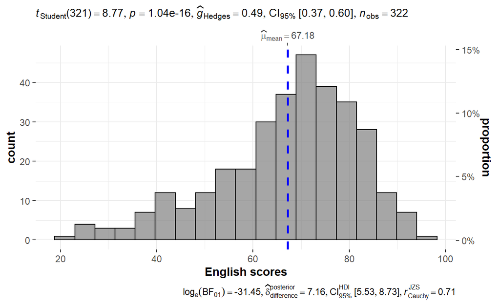

```r
set.seed(1234)

gghistostats(
  data = exam,
  x = ENGLISH,
  test.value = 60,
  xlab = "English scores"
)
```

Default information: * statistical details * Bayes Factor * sample sizes * distribution summary

Changing the *type of statistical approach/test*: paramatric(p), nonparamatric (np), robust(r), and bayes(b). Paramatric is default. *test.value* to indicate the true value of the mean.

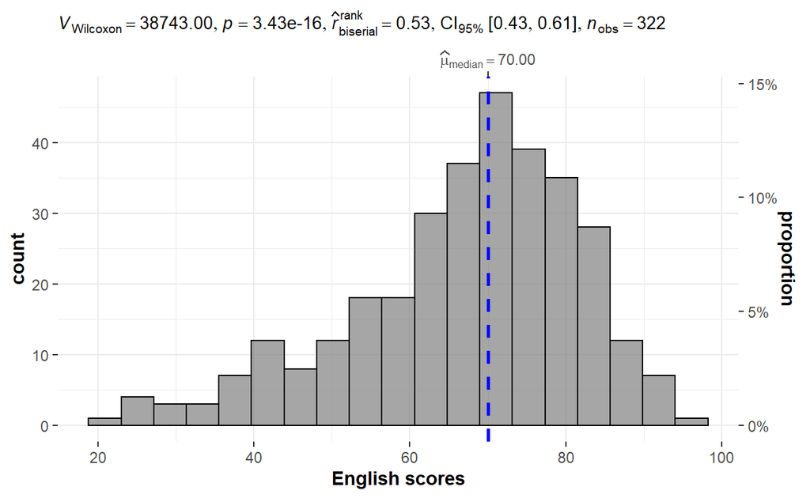

```r
set.seed(1234)

gghistostats(
  data = exam,
  x = ENGLISH,
  type = "np",
  test.value = 60,
  xlab = "English scores"
)
```

## Unpacking the Bayes Factor

- A Bayes factor is the ratio of the likelihood of one particular hypothesis to the likelihood of another. It can be interpreted as a measure of the strength of evidence in favor of one theory among two competing theories.
- That’s because the Bayes factor gives us a way to evaluate the data in favor of a null hypothesis, and to use external information to do so. It tells us what the weight of the evidence is in favor of a given hypothesis.
- When we are comparing two hypotheses, H1 (the alternate hypothesis) and H0 (the null hypothesis), the Bayes Factor is often written as B10. It can be defined mathematically as

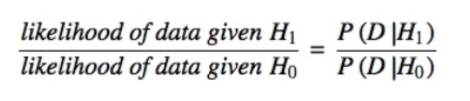

- The **Schwarz criterion** is one of the easiest ways to calculate rough approximation of the Bayes Factor.

### How to interpret Bayes Factor

A **Bayes Factor** can be any positive number. One of the most common interpretations is this one—first proposed by Harold Jeffereys (1961) and slightly modified by Lee and Wagenmakers in 2013:

[figure not shown]

## Two-sample mean test: ggbetweenstats()

In the code chunk below, *ggbetweenstats()* is used to build a visual for two-sample mean test of Maths scores by gender.

```r
ggbetweenstats(
  data = exam,
  x = GENDER,
  y = MATHS,
  messages = FALSE
)
```

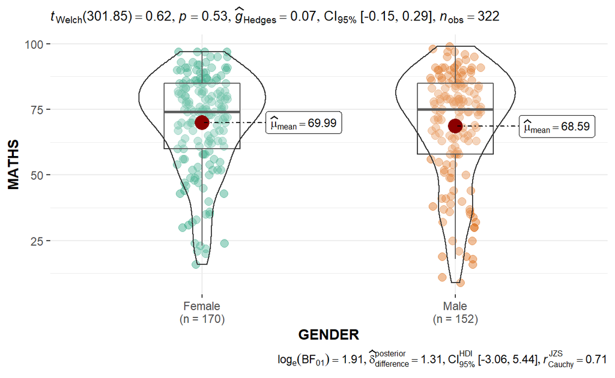

## Oneway ANOVA Test: ggbetweenstats()

In the code chunk below, ggbetweenstats() is used to build a visual for One-way ANOVA test on English score by race. To test more than 2 means.

```r
ggbetweenstats(
  data = exam,
  x = RACE,
  y = ENGLISH,
  type = "p",
  mean.ci = TRUE,
  pariwise.comparisons = TRUE,
  pairwise.display = "s",
  p.adjust.method = "fdr",
  messages = FALSE
)
```

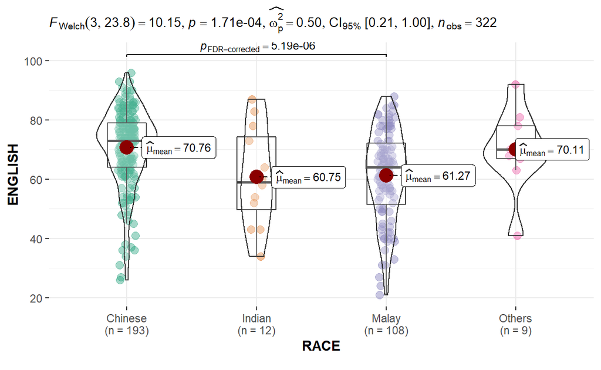

- “ns”: only show the pair that is only non-significant
- “s”: only show the pair that is only significant
- “all”: show all the pairs
- default significance level is 95% From this graph, it shows that only Chinese and Malay are significant

## Significant Test of Correlation: ggscatterstats()

In the code chunk below, *ggscatterstats()* is used to build a visual for Significant Test of Correlation between Maths scores and English scores. Both variables need to be **continuous**.

```r
ggscatterstats(
  data = exam,
  x = MATHS,
  y = ENGLISH,
  marginal = FALSE
)
```

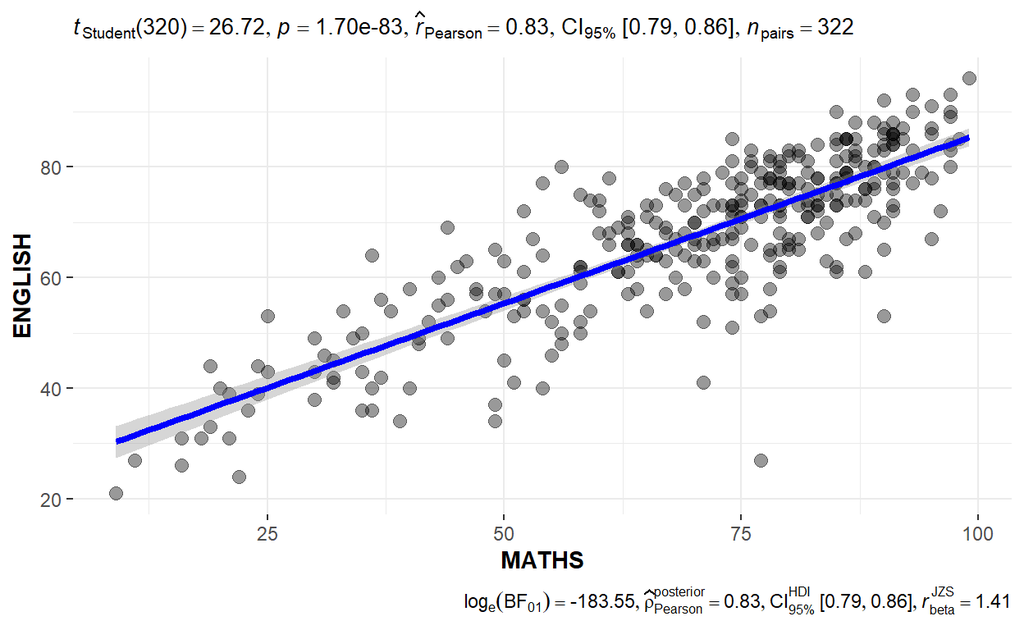

## Significant Test of Association (Depedence) : ggbarstats() methods

In the code chunk below, the Maths scores is binned into a 4-class variable by using *[cut()](https://www.rdocumentation.org/packages/base/versions/3.6.2/topics/cut)*, for discrete variables

```r
exam1 <- exam %>%
  mutate(MATHS_bins =
           cut(MATHS,
               breaks = c(0,60,75,85,100))
        )
```

In this code chunk below *[ggbarstats()](https://indrajeetpatil.github.io/ggstatsplot/reference/ggbarstats.html)* is used to build a visual for Significant Test of Association

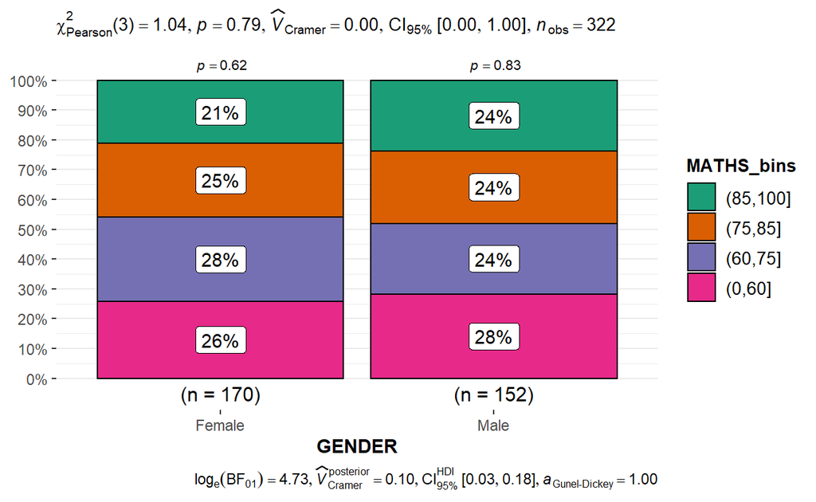

```r
ggbarstats(exam1,
           x = MATHS_bins,
           y = GENDER)
```

# Toyota Corolla case study

Build a model to discover factors affecting prices of used-cars by taking into consideration a set of explanatory variables.

## Installing and loading the required libraries

```r
packages = c('readxl', 'report', 'performance', 'parameters', 'see')
for(p in packages){
  if(!require(p, character.only = T)){
    install.packages(p)
  }
  library(p, character.only = T)
}
```

## Importing Excel file: readxl methods

In the code chunk below, *read_xls()* of readxl package is used to import the data worksheet of ToyotaCorolla.xls workbook into R.

```r
car_resale <- read_xls("data/ToyotaCorolla.xls", "data")
```

Notice that the output object car_resale is a tibble data frame.

### Multiple Regression Model using lm()

The code chunk below is used to calibrate a multiple linear regression model by using *lm()* of Base Stats of R.

```r
model <- lm(Price ~ Age_08_04 + Mfg_Year +KM +
              Weight + Guarantee_Period, data = car_resale)
model
```

```
Call:
lm(formula = Price ~ Age_08_04 + Mfg_Year + KM + Weight + Guarantee_Period,
    data = car_resale)

Coefficients:
     (Intercept)         Age_08_04          Mfg_Year
      -2.637e+06        -1.409e+01         1.315e+03
              KM            Weight  Guarantee_Period
      -2.323e-02         1.903e+01         2.770e+01
```

### Model Diagnostic: checking for multicolinearity

In the code chunk, *check_collinearity()* of **performance** package.

```r
check_collinearity(model)
```

```
# Check for Multicollinearity

Low Correlation

             Term  VIF Increased SE Tolerance
               KM 1.46         1.21      0.68
           Weight 1.41         1.19      0.71
 Guarantee_Period 1.04         1.02      0.97

High Correlation

      Term   VIF Increased SE Tolerance
 Age_08_04 31.07         5.57      0.03
  Mfg_Year 31.16         5.58      0.03
```

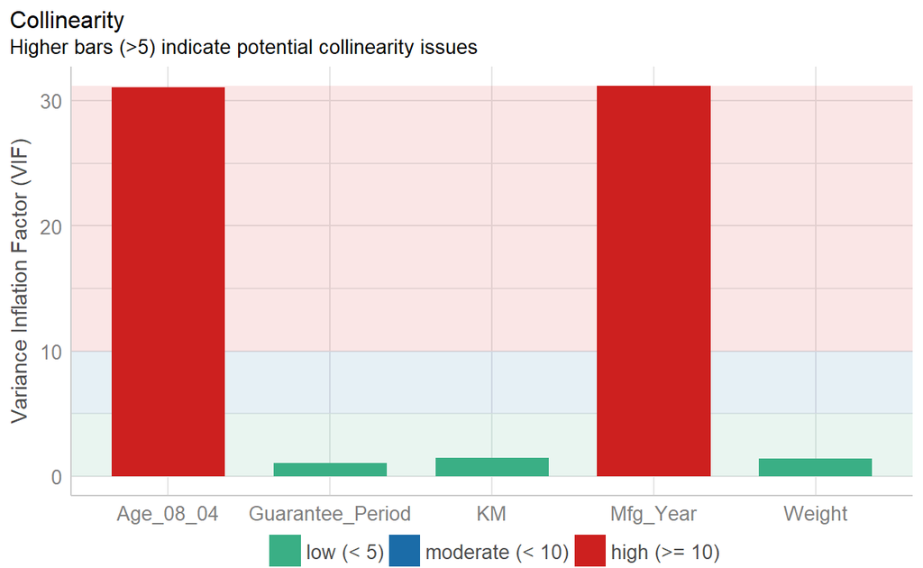

```r
check_c <- check_collinearity(model)
plot(check_c)
```

- no sign of multicollinearity –> green(<5)
- sign of high multicollinearity –> red(>=10)

### Model Diagnostic: checking normality assumption

In the code chunk, *check_normality()* of **performance** package.

```r
check_n <- check_normality(model)
```

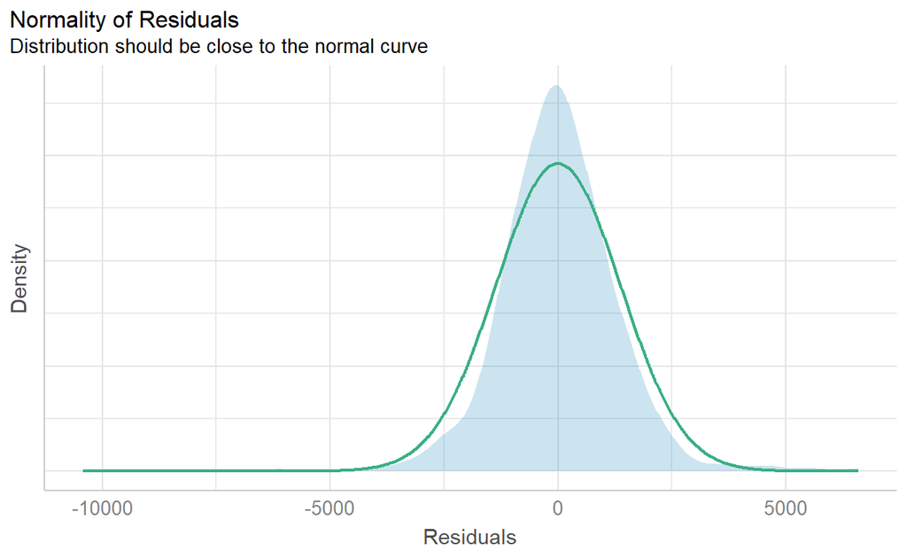

```r
plot(check_n)
```

### Model Diagnostic: Check model for homogeneity of variances

In the code chunk, *check_heteroscedasticity()* of **performance** package.

```r
check_h <- check_heteroscedasticity(model)
```

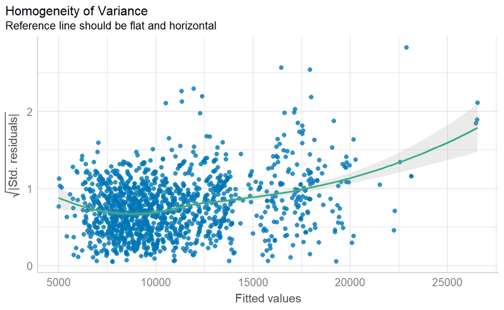

```r
plot(check_h)
```

### Model Diagnostic: Complete check

We can also perform the complete by using *check_model()*.

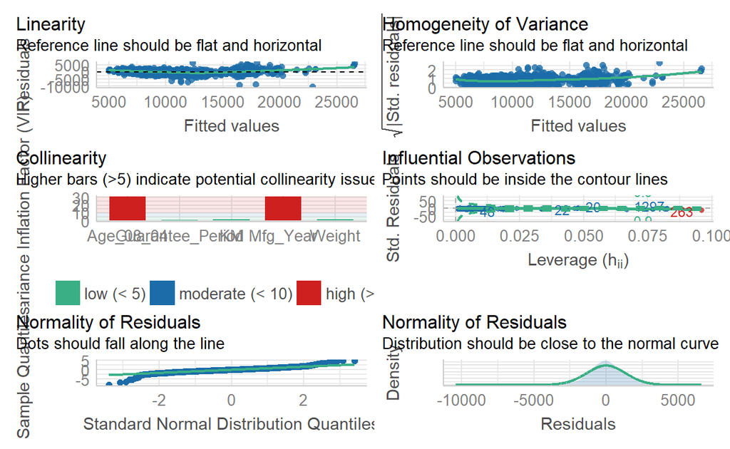

```r
check_model(model)
```

### Visualising Regression Parameters: see methods

In the code below, plot() of see package and parameters() of parameters package is used to visualise the parameters of a regression model. This is a better method as it shows both the positive and negative parts.

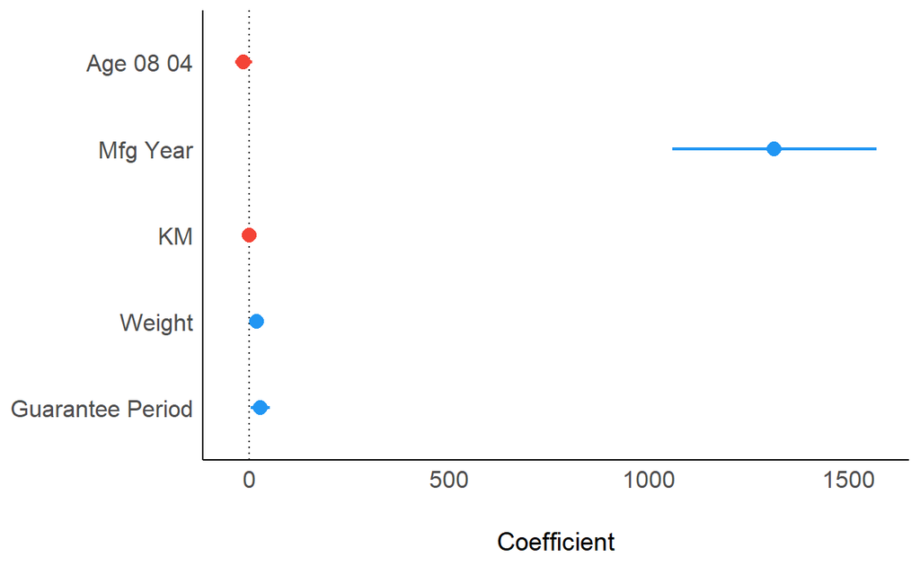

```r
plot(parameters(model))
```

### Visualising Regression Parameters: ggcoefstats() methods

In the code below, *ggcoefstats()* of ggstatsplot package to visualise the parameters of a regression model.

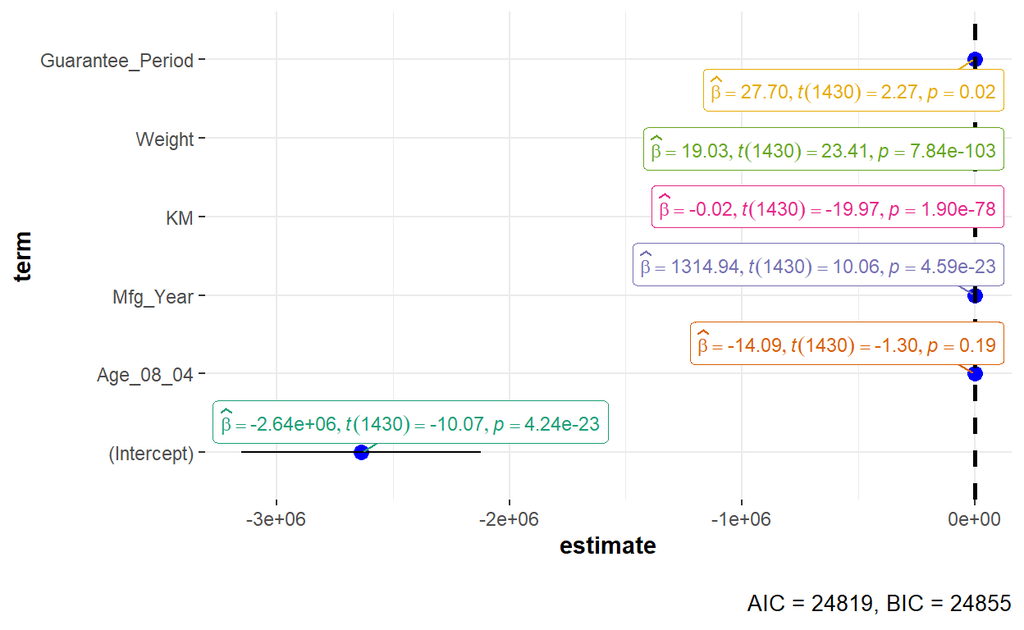

```r
ggcoefstats(model,
            output = "plot")
```

### Visualising uncertainty: ggdist package

- [ggdist](https://mjskay.github.io/ggdist/index.html) is an R package that provides a flexible set of ggplot2 geoms and stats designed especially for visualising distributions and uncertainty.
- It is designed for both frequentist and Bayesian uncertainty visualization, taking the view that uncertainty visualization can be unified through the perspective of distribution visualization:
  - for frequentist models, one visualises confidence distributions or bootstrap distributions (see vignette(“freq-uncertainty-vis”));
  - for Bayesian models, one visualises probability distributions (see the tidybayes package, which builds on top of ggdist).